# Machine Learning com scikit-learn no R

Pedro Lima

# Machine Learning com scikit-learn no R

## Scikit-learn

[figure not shown]

- Popular biblioteca de machine learning para Python;
- Vasto conjunto de algoritmos para processamento de dados e construção de modelos;
- Consistente, eficiente e de fácil utilização;
- Excelente documentação, repleta de exemplos e tutoriais.

# Ferramentas do scikit-learn

## Pré-processamento

- Seleção, transformação, criação de variáveis;
- Codificação de dados categorizados nominais e ordinais;
- Redução de dimensionalidade (PCA, FA etc.);
- Imputação de dados faltantes;
- Manipulação de dados em texto.
- etc.

## Modelos

- **Regressão:** linear, ridge, LASSO, SVR etc;
- **Classificação:** regressão logística, árvore de decisão, SVM, naive Bayes, LDA/QDA etc;
- **Clusterização:** K-Means, misturas gaussianas etc;
- **Outros:**
  - Estimação de densidades de probabilidade;
  - Decomposição de sinais;
  - Detecção de anomalias;
  - Redes neurais.

## Avaliação e seleção de modelos

- Particionamento dos dados em treino-teste;
- Métricas gerais de performance;
- Estimação de hiperparâmetros;
- Validação cruzada.

# Integrando o scikit-learn ao R

## Preparação

- O primeiro passo é carregar o pacote `reticulate` e indicar onde serão executados os códigos Python; nesse caso, no ambiente virtual “venv”.

```r
library(reticulate)
use_virtualenv("venv", required=TRUE)
```

- Caso precise criar esse ambiente virtual, primeiro execute:

```r
use_python("C:/Users/user/anaconda3")
virtualenv_create("venv",
                  packages=c("scikit-learn",
                             "numpy", "pandas"))
```

## Exemplo: classificação de tumores de mama

```r
library(readr)
breast_cancer <- read_csv("breast_cancer.csv")
```

```r
head(breast_cancer)
```

```
# A tibble: 6 x 31
  `mean radius` `mean texture` `mean perimeter` `mean area` `mean smoothness`
          <dbl>          <dbl>            <dbl>       <dbl>             <dbl>
1          18.0           10.4            123.        1001             0.118
2          20.6           17.8            133.        1326             0.0847
3          19.7           21.2            130         1203             0.110
4          11.4           20.4             77.6        386.            0.142
5          20.3           14.3            135.        1297             0.100
6          12.4           15.7             82.6        477.            0.128
# ... with 26 more variables: `mean compactness` <dbl>, `mean concavity` <dbl>,
#   `mean concave points` <dbl>, `mean symmetry` <dbl>,
#   `mean fractal dimension` <dbl>, `radius error` <dbl>,
#   `texture error` <dbl>, `perimeter error` <dbl>, `area error` <dbl>,
#   `smoothness error` <dbl>, `compactness error` <dbl>,
#   `concavity error` <dbl>, `concave points error` <dbl>,
#   `symmetry error` <dbl>, `fractal dimension error` <dbl>, ...
```

- O objetivo é identificar se um tumor é maligno (câncer de mama) ou benigno.

No scikit-learn, para ajustar um modelo é preciso separar covariáveis, representadas pela data frame `X`, e variável resposta `y`.

```r
library(dplyr)
X <- select(breast_cancer, -y)
y <- select(breast_cancer, y) # 0 = maligno, 1 = benigno
```

## Divisão em treino e teste

- No contexto de machine learning, é rotineiro separar uma parte dos dados para testar a capacidade de um modelo, geralmente, 20% das observações. Isso pode ser feito do seguinte modo no sklearn:

```r
model_sel <- import("sklearn.model_selection")

py_set_seed(42)
split <- model_sel$train_test_split(X, y, test_size=0.20)

X_train <- split[[1]]; X_test <- split[[2]]
y_train <- split[[3]]; y_test <- split[[4]]
```

> A função `py_set_seed` fixa a semente dos geradores de números aleatórios do Python para a reprodução de resultados.

## O modelo de classificação

- Um possível modelo consiste na padronização das variáveis, seguida da retenção dos cinco componentes principais de maior variação e sobre eles um Support Vector Machine.

```r
pipe <- import("sklearn.pipeline")
preproc <- import("sklearn.preprocessing")
decomp <- import("sklearn.decomposition")
svm <- import("sklearn.svm")

model <- pipe$make_pipeline(
  preproc$StandardScaler(),         # Padronização
  decomp$PCA(n_components=5L),      # Componentes principais
  svm$LinearSVC(C=8.71, dual=FALSE) # Support Vector Machine
)
```

- O **pipeline** é análogo ao pipe `%>%` do R:
  - Sequência de transformações, seguida de um modelo;
  - Unifica e simplifica as etapas de pré-processamento, estimação e ajuste de hiperparâmetros, e previsões.

## Ajuste do modelo

- > Os hiperparâmetros `n_components` e `C` definidos podem ser ajustados utilizando métodos de [validação cruzada](https://scikit-learn.org/stable/modules/cross_validation.html) (Grid Search, Random Search etc.) sobre o pipeline.
- Com os hiperparâmetros definidos, ajusta-se o modelo aos dados de **treino**.

```r
model$fit(X_train, y_train)
```

- > **(Vazamento de dados)**. O pipeline ajuda a reforçar o uso de apenas os dados de **treino** para o ajuste.

## Performance do modelo

- Agora, a verificação da qualidade das previsões por meio da acurácia no conjunto de **teste**.

```r
metrics <- import("sklearn.metrics")
y_pred_test <- model$predict(X_test)

metrics$accuracy_score(y_test, y_pred_test)
```

```
[1] 0.9824561
```

- > O scikit-learn dispõe de outras [métricas](https://scikit-learn.org/stable/modules/classes.html?highlight=metrics#classification-metrics) de performance para modelos de classificação, tais como: acurácia balanceada, precisão, recall, F1 etc.
- Como estamos num ambiente R, podemos usar de forma natural o `ggplot2` e fazer uma comparação gráfica entre o que foi observado e as previsões.

```r
test_data <- X_test
test_data["y"] <- y_test
test_data["y_pred"] <- y_pred_test

library(ggplot2)
ggplot(data=test_data, aes(x=y_pred, y=y))+
  geom_jitter()
```

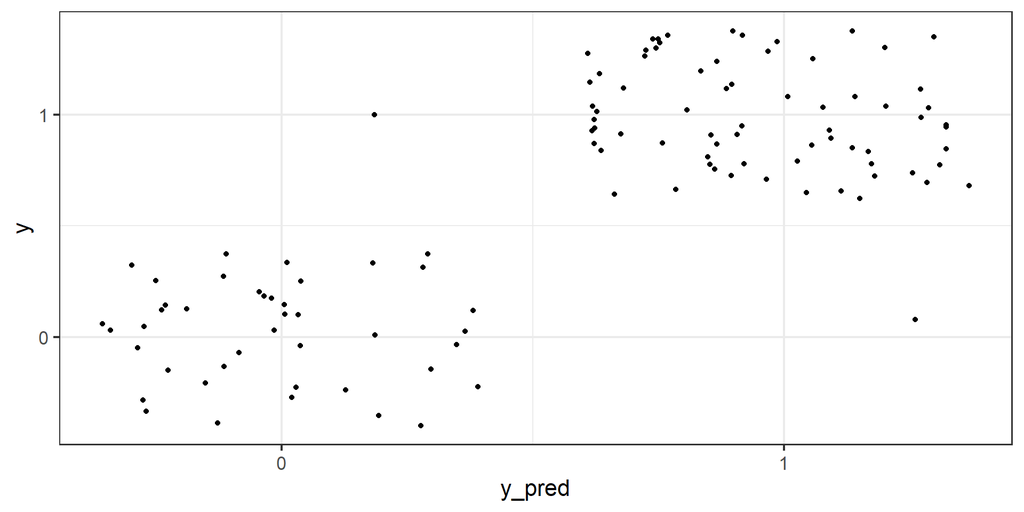

# Materiais

1. Para mais informações sobre a biblioteca scikit-learn, veja sua [página na web](https://scikit-learn.org/stable/getting_started.html) e o [guia de usuário](https://scikit-learn.org/stable/user_guide.html);
2. [Como Usar Pipelines no Scikit-Learn - João Paulo Nogueira](https://medium.com/data-hackers/como-usar-pipelines-no-scikit-learn-1398a4cc6ae9);
3. [Cross Validation - scikit-learn](https://scikit-learn.org/stable/modules/cross_validation.html);
4. [GÉRON, Aurélien (2019)](https://www.oreilly.com/library/view/hands-on-machine-learning/9781492032632/). Hands-On Machine Learning with Scikit-Learn, Keras, and TensorFlow;
5. [Translating between tidymodels and scikit-learn - Kelly Bodwin](https://www.kelly-bodwin.com/talks/rsconf22/).